# Transfer learning on the pre-train model

**Project flow**

- Data loading and preprocessing
- Model preperation
- Fine Tuening and training
- Model evaluation
- Comparision of the result
- Prediction using the best fit model

## About the data set and pre training models

**Dataset**  
I am using the cifar100 data set which is a set of images of `32X32`(3 channel) to train my model to identify the images.  
The images has 100 labels i.e. there are image of 100 different type of object, animals, people etc.  
The data set is of 50000 training image and 10000 testing images.

**Models**  
I am testing the cifar 100 dataset on three pre train models. These are

- Restnet (Resiudal Network)
- VGG16
- Mobilenet V2 - This is a lighter version of the image processing model

All of these three models are pretrain on imagenet dataset

## Loading the libraires and Data

```
import numpy as np
import tensorflow as tf
from tensorflow.keras.datasets import cifar100
from tensorflow.keras.applications.resnet50 import preprocess_input as preprocess_resnet50
from tensorflow.keras.applications.vgg16 import preprocess_input as preprocess_vgg16
from tensorflow.keras.applications.mobilenet_v2 import preprocess_input as preprocess_mobilenetv2
(X_train, y_train),(X_test,y_test) = cifar100.load_data()
```

##### **Checking the shape of the training and testing dataset**

```
------------------------------
The shape of the training dataset (50000, 32, 32, 3)
The shape of the training data label (50000, 1)
The shape of the testing dataset (10000, 32, 32, 3)
The shape of the testing data label (10000, 1)
------------------------------
```

##### **Sample images in the training data**

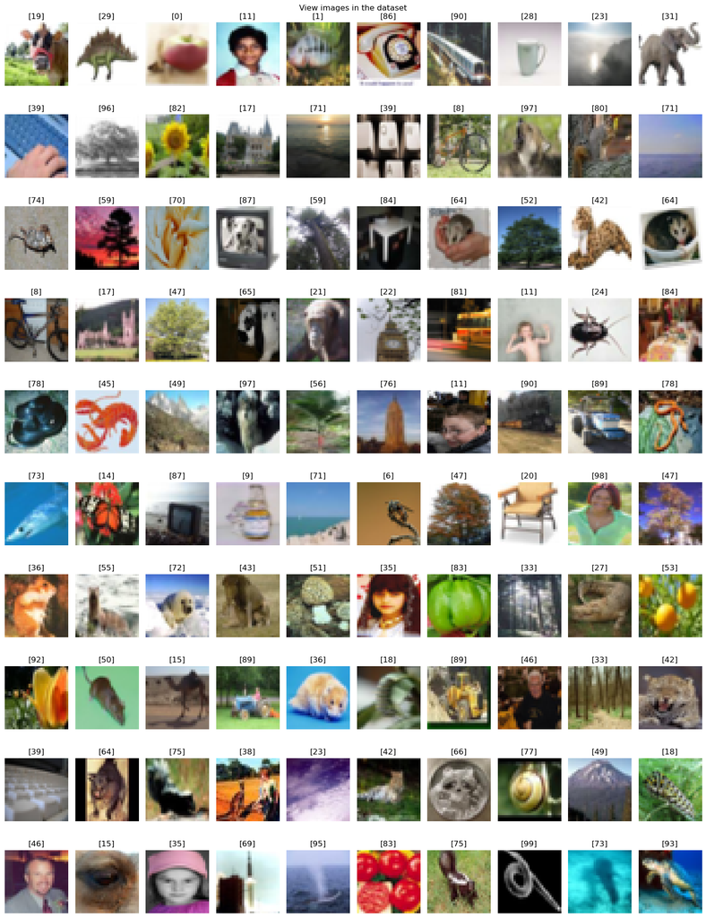

## Preprocessing the data set according to the features of the model imput images

```
X_train_resnet50 = preprocess_resnet50(X_train)
X_train_vgg16 = preprocess_vgg16(X_train)
X_train_mobilenetv2 = preprocess_mobilenetv2(X_train)
X_test_resnet50 = preprocess_resnet50(X_test)
X_test_vgg16 = preprocess_vgg16(X_test)
X_test_mobilenetv2 = preprocess_mobilenetv2(X_test)
```

##### **Shape of the data after preprocessing**

```
------------------------------
The shape of the training dataset after preprocessing (50000, 32, 32, 3)
The shape of the testing dataset after preprocessing (10000, 32, 32, 3)
The shape of the training dataset after preprocessing (50000, 32, 32, 3)
The shape of the testing dataset after preprocessing (10000, 32, 32, 3)
The shape of the training dataset after preprocessing (50000, 32, 32, 3)
The shape of the testing dataset after preprocessing (10000, 32, 32, 3)
------------------------------
```

## Model preperation

Load and modify pre-trained models to fit the CIFAR-100 classification task.

##### **Using ResNet50**

```
base_model_resnet50 = ResNet50(weights='imagenet', include_top=False, input_shape=(32, 32, 3))
model_resnet50 = Model(inputs = base_model_resnet50.input, outputs = predictions)
model_resnet50.compile(optimizer='adam', loss = 'sparse_categorical_crossentropy', metrics = ['accuracy'])
```

```
----------------------------------------------------------------------------------------------------
Total params: 25,788,388 (98.37 MB)
Trainable params: 25,735,268 (98.17 MB)
Non-trainable params: 53,120 (207.50 KB)
----------------------------------------------------------------------------------------------------
model_resnet50.summary()
```

```
Model: "functional"
```

```
┏━━━━━━━━━━━━━━━━━━━━━━━━━━━━━━━┳━━━━━━━━━━━━━━━━━━━━━━━━━━━┳━━━━━━━━━━━━━━━━━┳━━━━━━━━━━━━━━━━━━━━━━━━━━━━┓
┃ Layer (type)                  ┃ Output Shape              ┃         Param # ┃ Connected to               ┃
┡━━━━━━━━━━━━━━━━━━━━━━━━━━━━━━━╇━━━━━━━━━━━━━━━━━━━━━━━━━━━╇━━━━━━━━━━━━━━━━━╇━━━━━━━━━━━━━━━━━━━━━━━━━━━━┩
│ input_layer (InputLayer)      │ (None, 32, 32, 3)         │               0 │ -                          │
├───────────────────────────────┼───────────────────────────┼─────────────────┼────────────────────────────┤
│ conv1_pad (ZeroPadding2D)     │ (None, 38, 38, 3)         │               0 │ input_layer[0][0]          │
├───────────────────────────────┼───────────────────────────┼─────────────────┼────────────────────────────┤
│ conv1_conv (Conv2D)           │ (None, 16, 16, 64)        │           9,472 │ conv1_pad[0][0]            │
├───────────────────────────────┼───────────────────────────┼─────────────────┼────────────────────────────┤
│ conv1_bn (BatchNormalization) │ (None, 16, 16, 64)        │             256 │ conv1_conv[0][0]           │
├───────────────────────────────┼───────────────────────────┼─────────────────┼────────────────────────────┤
│ conv1_relu (Activation)       │ (None, 16, 16, 64)        │               0 │ conv1_bn[0][0]             │
├───────────────────────────────┼───────────────────────────┼─────────────────┼────────────────────────────┤
│ pool1_pad (ZeroPadding2D)     │ (None, 18, 18, 64)        │               0 │ conv1_relu[0][0]           │
├───────────────────────────────┼───────────────────────────┼─────────────────┼────────────────────────────┤
│ pool1_pool (MaxPooling2D)     │ (None, 8, 8, 64)          │               0 │ pool1_pad[0][0]            │
├───────────────────────────────┼───────────────────────────┼─────────────────┼────────────────────────────┤
│ conv2_block1_1_conv (Conv2D)  │ (None, 8, 8, 64)          │           4,160 │ pool1_pool[0][0]           │
├───────────────────────────────┼───────────────────────────┼─────────────────┼────────────────────────────┤
│ conv2_block1_1_bn             │ (None, 8, 8, 64)          │             256 │ conv2_block1_1_conv[0][0]  │
│ (BatchNormalization)          │                           │                 │                            │
├───────────────────────────────┼───────────────────────────┼─────────────────┼────────────────────────────┤
│ conv2_block1_1_relu           │ (None, 8, 8, 64)          │               0 │ conv2_block1_1_bn[0][0]    │
│ (Activation)                  │                           │                 │                            │
├───────────────────────────────┼───────────────────────────┼─────────────────┼────────────────────────────┤
│ conv2_block1_2_conv (Conv2D)  │ (None, 8, 8, 64)          │          36,928 │ conv2_block1_1_relu[0][0]  │
├───────────────────────────────┼───────────────────────────┼─────────────────┼────────────────────────────┤
│ conv2_block1_2_bn             │ (None, 8, 8, 64)          │             256 │ conv2_block1_2_conv[0][0]  │
│ (BatchNormalization)          │                           │                 │                            │
├───────────────────────────────┼───────────────────────────┼─────────────────┼────────────────────────────┤
│ conv2_block1_2_relu           │ (None, 8, 8, 64)          │               0 │ conv2_block1_2_bn[0][0]    │
│ (Activation)                  │                           │                 │                            │
├───────────────────────────────┼───────────────────────────┼─────────────────┼────────────────────────────┤
│ conv2_block1_0_conv (Conv2D)  │ (None, 8, 8, 256)         │          16,640 │ pool1_pool[0][0]           │
├───────────────────────────────┼───────────────────────────┼─────────────────┼────────────────────────────┤
│ conv2_block1_3_conv (Conv2D)  │ (None, 8, 8, 256)         │          16,640 │ conv2_block1_2_relu[0][0]  │
├───────────────────────────────┼───────────────────────────┼─────────────────┼────────────────────────────┤
│ conv2_block1_0_bn             │ (None, 8, 8, 256)         │           1,024 │ conv2_block1_0_conv[0][0]  │
│ (BatchNormalization)          │                           │                 │                            │
├───────────────────────────────┼───────────────────────────┼─────────────────┼────────────────────────────┤
```

[output cut: 405 more lines]

```
│ conv5_block3_3_bn             │ (None, 1, 1, 2048)        │           8,192 │ conv5_block3_3_conv[0][0]  │
│ (BatchNormalization)          │                           │                 │                            │
├───────────────────────────────┼───────────────────────────┼─────────────────┼────────────────────────────┤
│ conv5_block3_add (Add)        │ (None, 1, 1, 2048)        │               0 │ conv5_block2_out[0][0],    │
│                               │                           │                 │ conv5_block3_3_bn[0][0]    │
├───────────────────────────────┼───────────────────────────┼─────────────────┼────────────────────────────┤
│ conv5_block3_out (Activation) │ (None, 1, 1, 2048)        │               0 │ conv5_block3_add[0][0]     │
├───────────────────────────────┼───────────────────────────┼─────────────────┼────────────────────────────┤
│ global_average_pooling2d      │ (None, 2048)              │               0 │ conv5_block3_out[0][0]     │
│ (GlobalAveragePooling2D)      │                           │                 │                            │
├───────────────────────────────┼───────────────────────────┼─────────────────┼────────────────────────────┤
│ dense (Dense)                 │ (None, 1024)              │       2,098,176 │ global_average_pooling2d[… │
├───────────────────────────────┼───────────────────────────┼─────────────────┼────────────────────────────┤
│ dense_1 (Dense)               │ (None, 100)               │         102,500 │ dense[0][0]                │
└───────────────────────────────┴───────────────────────────┴─────────────────┴────────────────────────────┘
```

```
 Total params: 25,788,388 (98.37 MB)
```

```
 Trainable params: 25,735,268 (98.17 MB)
```

```
 Non-trainable params: 53,120 (207.50 KB)
```

##### **Using VGG16**

```
base_model_vgg16 = VGG16(weights = 'imagenet', include_top = False, input_shape=(32,32,3))
model_vgg16 = Model(inputs = base_model_vgg16.input, outputs = predictions)
model_vgg16.compile(optimizer = 'adam', loss = 'sparse_categorical_crossentropy', metrics = ['accuracy'])
```

```
----------------------------------------------------------------------------------------------------
Total params: 15,028,644 (57.33 MB)
Trainable params: 15,028,644 (57.33 MB)
Non-trainable params: 0 (0.00 B)
----------------------------------------------------------------------------------------------------
model_vgg16.summary()
```

```
Model: "functional_1"
```

```
┏━━━━━━━━━━━━━━━━━━━━━━━━━━━━━━━━━━━━━━┳━━━━━━━━━━━━━━━━━━━━━━━━━━━━━┳━━━━━━━━━━━━━━━━━┓
┃ Layer (type)                         ┃ Output Shape                ┃         Param # ┃
┡━━━━━━━━━━━━━━━━━━━━━━━━━━━━━━━━━━━━━━╇━━━━━━━━━━━━━━━━━━━━━━━━━━━━━╇━━━━━━━━━━━━━━━━━┩
│ input_layer_1 (InputLayer)           │ (None, 32, 32, 3)           │               0 │
├──────────────────────────────────────┼─────────────────────────────┼─────────────────┤
│ block1_conv1 (Conv2D)                │ (None, 32, 32, 64)          │           1,792 │
├──────────────────────────────────────┼─────────────────────────────┼─────────────────┤
│ block1_conv2 (Conv2D)                │ (None, 32, 32, 64)          │          36,928 │
├──────────────────────────────────────┼─────────────────────────────┼─────────────────┤
│ block1_pool (MaxPooling2D)           │ (None, 16, 16, 64)          │               0 │
├──────────────────────────────────────┼─────────────────────────────┼─────────────────┤
│ block2_conv1 (Conv2D)                │ (None, 16, 16, 128)         │          73,856 │
├──────────────────────────────────────┼─────────────────────────────┼─────────────────┤
│ block2_conv2 (Conv2D)                │ (None, 16, 16, 128)         │         147,584 │
├──────────────────────────────────────┼─────────────────────────────┼─────────────────┤
│ block2_pool (MaxPooling2D)           │ (None, 8, 8, 128)           │               0 │
├──────────────────────────────────────┼─────────────────────────────┼─────────────────┤
│ block3_conv1 (Conv2D)                │ (None, 8, 8, 256)           │         295,168 │
├──────────────────────────────────────┼─────────────────────────────┼─────────────────┤
│ block3_conv2 (Conv2D)                │ (None, 8, 8, 256)           │         590,080 │
├──────────────────────────────────────┼─────────────────────────────┼─────────────────┤
│ block3_conv3 (Conv2D)                │ (None, 8, 8, 256)           │         590,080 │
├──────────────────────────────────────┼─────────────────────────────┼─────────────────┤
│ block3_pool (MaxPooling2D)           │ (None, 4, 4, 256)           │               0 │
├──────────────────────────────────────┼─────────────────────────────┼─────────────────┤
│ block4_conv1 (Conv2D)                │ (None, 4, 4, 512)           │       1,180,160 │
├──────────────────────────────────────┼─────────────────────────────┼─────────────────┤
│ block4_conv2 (Conv2D)                │ (None, 4, 4, 512)           │       2,359,808 │
├──────────────────────────────────────┼─────────────────────────────┼─────────────────┤
│ block4_conv3 (Conv2D)                │ (None, 4, 4, 512)           │       2,359,808 │
├──────────────────────────────────────┼─────────────────────────────┼─────────────────┤
│ block4_pool (MaxPooling2D)           │ (None, 2, 2, 512)           │               0 │
├──────────────────────────────────────┼─────────────────────────────┼─────────────────┤
│ block5_conv1 (Conv2D)                │ (None, 2, 2, 512)           │       2,359,808 │
├──────────────────────────────────────┼─────────────────────────────┼─────────────────┤
│ block5_conv2 (Conv2D)                │ (None, 2, 2, 512)           │       2,359,808 │
├──────────────────────────────────────┼─────────────────────────────┼─────────────────┤
│ block5_conv3 (Conv2D)                │ (None, 2, 2, 512)           │       2,359,808 │
├──────────────────────────────────────┼─────────────────────────────┼─────────────────┤
│ block5_pool (MaxPooling2D)           │ (None, 1, 1, 512)           │               0 │
├──────────────────────────────────────┼─────────────────────────────┼─────────────────┤
│ global_average_pooling2d_1           │ (None, 512)                 │               0 │
│ (GlobalAveragePooling2D)             │                             │                 │
├──────────────────────────────────────┼─────────────────────────────┼─────────────────┤
│ dense_2 (Dense)                      │ (None, 512)                 │         262,656 │
├──────────────────────────────────────┼─────────────────────────────┼─────────────────┤
│ dense_3 (Dense)                      │ (None, 100)                 │          51,300 │
└──────────────────────────────────────┴─────────────────────────────┴─────────────────┘
```

```
 Total params: 15,028,644 (57.33 MB)
```

```
 Trainable params: 15,028,644 (57.33 MB)
```

```
 Non-trainable params: 0 (0.00 B)
```

##### **Using MobileNet V2**

```
base_model_mobilenetv2 = MobileNetV2(weights='imagenet', include_top=False, input_shape=(32, 32, 3))
model_mobilenetv2 = Model(inputs = base_model_mobilenetv2.input, outputs = predictions)
model_mobilenetv2.compile(optimizer = 'adam', loss = 'sparse_categorical_crossentropy', metrics = ['accuracy'])
```

```
----------------------------------------------------------------------------------------------------
Total params: 3,672,228 (14.01 MB)
Trainable params: 3,638,116 (13.88 MB)
Non-trainable params: 34,112 (133.25 KB)
----------------------------------------------------------------------------------------------------
model_mobilenetv2.summary()
```

```
Model: "functional_2"
```

```
┏━━━━━━━━━━━━━━━━━━━━━━━━━━━━━━━┳━━━━━━━━━━━━━━━━━━━━━━━━━━━┳━━━━━━━━━━━━━━━━━┳━━━━━━━━━━━━━━━━━━━━━━━━━━━━┓
┃ Layer (type)                  ┃ Output Shape              ┃         Param # ┃ Connected to               ┃
┡━━━━━━━━━━━━━━━━━━━━━━━━━━━━━━━╇━━━━━━━━━━━━━━━━━━━━━━━━━━━╇━━━━━━━━━━━━━━━━━╇━━━━━━━━━━━━━━━━━━━━━━━━━━━━┩
│ input_layer_2 (InputLayer)    │ (None, 32, 32, 3)         │               0 │ -                          │
├───────────────────────────────┼───────────────────────────┼─────────────────┼────────────────────────────┤
│ Conv1 (Conv2D)                │ (None, 16, 16, 32)        │             864 │ input_layer_2[0][0]        │
├───────────────────────────────┼───────────────────────────┼─────────────────┼────────────────────────────┤
│ bn_Conv1 (BatchNormalization) │ (None, 16, 16, 32)        │             128 │ Conv1[0][0]                │
├───────────────────────────────┼───────────────────────────┼─────────────────┼────────────────────────────┤
│ Conv1_relu (ReLU)             │ (None, 16, 16, 32)        │               0 │ bn_Conv1[0][0]             │
├───────────────────────────────┼───────────────────────────┼─────────────────┼────────────────────────────┤
│ expanded_conv_depthwise       │ (None, 16, 16, 32)        │             288 │ Conv1_relu[0][0]           │
│ (DepthwiseConv2D)             │                           │                 │                            │
├───────────────────────────────┼───────────────────────────┼─────────────────┼────────────────────────────┤
│ expanded_conv_depthwise_BN    │ (None, 16, 16, 32)        │             128 │ expanded_conv_depthwise[0… │
│ (BatchNormalization)          │                           │                 │                            │
├───────────────────────────────┼───────────────────────────┼─────────────────┼────────────────────────────┤
│ expanded_conv_depthwise_relu  │ (None, 16, 16, 32)        │               0 │ expanded_conv_depthwise_B… │
│ (ReLU)                        │                           │                 │                            │
├───────────────────────────────┼───────────────────────────┼─────────────────┼────────────────────────────┤
│ expanded_conv_project         │ (None, 16, 16, 16)        │             512 │ expanded_conv_depthwise_r… │
│ (Conv2D)                      │                           │                 │                            │
├───────────────────────────────┼───────────────────────────┼─────────────────┼────────────────────────────┤
│ expanded_conv_project_BN      │ (None, 16, 16, 16)        │              64 │ expanded_conv_project[0][… │
│ (BatchNormalization)          │                           │                 │                            │
├───────────────────────────────┼───────────────────────────┼─────────────────┼────────────────────────────┤
│ block_1_expand (Conv2D)       │ (None, 16, 16, 96)        │           1,536 │ expanded_conv_project_BN[… │
├───────────────────────────────┼───────────────────────────┼─────────────────┼────────────────────────────┤
│ block_1_expand_BN             │ (None, 16, 16, 96)        │             384 │ block_1_expand[0][0]       │
│ (BatchNormalization)          │                           │                 │                            │
├───────────────────────────────┼───────────────────────────┼─────────────────┼────────────────────────────┤
│ block_1_expand_relu (ReLU)    │ (None, 16, 16, 96)        │               0 │ block_1_expand_BN[0][0]    │
├───────────────────────────────┼───────────────────────────┼─────────────────┼────────────────────────────┤
│ block_1_pad (ZeroPadding2D)   │ (None, 17, 17, 96)        │               0 │ block_1_expand_relu[0][0]  │
├───────────────────────────────┼───────────────────────────┼─────────────────┼────────────────────────────┤
│ block_1_depthwise             │ (None, 8, 8, 96)          │             864 │ block_1_pad[0][0]          │
│ (DepthwiseConv2D)             │                           │                 │                            │
├───────────────────────────────┼───────────────────────────┼─────────────────┼────────────────────────────┤
│ block_1_depthwise_BN          │ (None, 8, 8, 96)          │             384 │ block_1_depthwise[0][0]    │
│ (BatchNormalization)          │                           │                 │                            │
```

[output cut: 350 more lines]

```
├───────────────────────────────┼───────────────────────────┼─────────────────┼────────────────────────────┤
│ Conv_1 (Conv2D)               │ (None, 1, 1, 1280)        │         409,600 │ block_16_project_BN[0][0]  │
├───────────────────────────────┼───────────────────────────┼─────────────────┼────────────────────────────┤
│ Conv_1_bn                     │ (None, 1, 1, 1280)        │           5,120 │ Conv_1[0][0]               │
│ (BatchNormalization)          │                           │                 │                            │
├───────────────────────────────┼───────────────────────────┼─────────────────┼────────────────────────────┤
│ out_relu (ReLU)               │ (None, 1, 1, 1280)        │               0 │ Conv_1_bn[0][0]            │
├───────────────────────────────┼───────────────────────────┼─────────────────┼────────────────────────────┤
│ global_average_pooling2d_2    │ (None, 1280)              │               0 │ out_relu[0][0]             │
│ (GlobalAveragePooling2D)      │                           │                 │                            │
├───────────────────────────────┼───────────────────────────┼─────────────────┼────────────────────────────┤
│ dense_4 (Dense)               │ (None, 1024)              │       1,311,744 │ global_average_pooling2d_… │
├───────────────────────────────┼───────────────────────────┼─────────────────┼────────────────────────────┤
│ dense_5 (Dense)               │ (None, 100)               │         102,500 │ dense_4[0][0]              │
└───────────────────────────────┴───────────────────────────┴─────────────────┴────────────────────────────┘
```

```
 Total params: 3,672,228 (14.01 MB)
```

```
 Trainable params: 3,638,116 (13.88 MB)
```

```
 Non-trainable params: 34,112 (133.25 KB)
```

## Fine tuning (Training the model on cifar dataset)

This is also called as transfer learning since the model already has the weight of the imagenet dataset. I am adjusting weight of the last few layers of the network based on my own dataset I will train the model for 30 epoch using the early_stopping methods to avoid any unnecessary epoch which may not improve the model

##### **ResNet50**

```
----------------------------------------------------------------------------------------------------
Length of the ResNet50 base model 178 .
I will be using only last 18 layer to fine tune the model for Cifar100 dataset.
----------------------------------------------------------------------------------------------------
```

```
Fine-tuning ResNet50...
1563/1563 ━━━━━━━━━━━━━━━━━━━━ 0s 299ms/step - accuracy: 0.2875 - loss: 3.1208
Epoch 1: val_loss improved from None to 2.39195, saving model to best_weight_resnet50.weights.h5

Epoch 1: finished saving model to best_weight_resnet50.weights.h5
1563/1563 ━━━━━━━━━━━━━━━━━━━━ 538s 332ms/step - accuracy: 0.3427 - loss: 2.6518 - val_accuracy: 0.3843 - val_loss: 2.3919
1563/1563 ━━━━━━━━━━━━━━━━━━━━ 0s 300ms/step - accuracy: 0.4930 - loss: 1.8556
Epoch 2: val_loss did not improve from 2.39195
1563/1563 ━━━━━━━━━━━━━━━━━━━━ 516s 330ms/step - accuracy: 0.4780 - loss: 1.9183 - val_accuracy: 0.3952 - val_loss: 2.4728
1563/1563 ━━━━━━━━━━━━━━━━━━━━ 0s 292ms/step - accuracy: 0.6187 - loss: 1.3260
Epoch 3: val_loss did not improve from 2.39195
1563/1563 ━━━━━━━━━━━━━━━━━━━━ 501s 320ms/step - accuracy: 0.5933 - loss: 1.4227 - val_accuracy: 0.3918 - val_loss: 2.6151
1563/1563 ━━━━━━━━━━━━━━━━━━━━ 0s 278ms/step - accuracy: 0.7520 - loss: 0.8411
Epoch 4: val_loss did not improve from 2.39195
1563/1563 ━━━━━━━━━━━━━━━━━━━━ 480s 307ms/step - accuracy: 0.7245 - loss: 0.9298 - val_accuracy: 0.3982 - val_loss: 2.9890
Epoch 4: early stopping
Restoring model weights from the end of the best epoch: 1.
Fine-tuning ResNet50 completed.
```

##### **VGG16**

```
----------------------------------------------------------------------------------------------------
Length of the VGG16 base model 22 .
I will be using only last 2 layer to fine tune the model for Cifar100 dataset.
----------------------------------------------------------------------------------------------------
```

```
Fine-tuning VGG16...
1563/1563 ━━━━━━━━━━━━━━━━━━━━ 0s 221ms/step - accuracy: 0.0877 - loss: 6.7908
Epoch 1: val_loss improved from None to 3.59384, saving model to best_weight_vgg16.weights.h5

Epoch 1: finished saving model to best_weight_vgg16.weights.h5
1563/1563 ━━━━━━━━━━━━━━━━━━━━ 410s 260ms/step - accuracy: 0.0986 - loss: 4.5818 - val_accuracy: 0.1364 - val_loss: 3.5938
1563/1563 ━━━━━━━━━━━━━━━━━━━━ 0s 235ms/step - accuracy: 0.1474 - loss: 3.4626
Epoch 2: val_loss improved from 3.59384 to 3.16528, saving model to best_weight_vgg16.weights.h5

Epoch 2: finished saving model to best_weight_vgg16.weights.h5
1563/1563 ━━━━━━━━━━━━━━━━━━━━ 458s 271ms/step - accuracy: 0.1655 - loss: 3.3422 - val_accuracy: 0.1897 - val_loss: 3.1653
1563/1563 ━━━━━━━━━━━━━━━━━━━━ 0s 244ms/step - accuracy: 0.2096 - loss: 3.0666
Epoch 3: val_loss improved from 3.16528 to 2.98580, saving model to best_weight_vgg16.weights.h5

Epoch 3: finished saving model to best_weight_vgg16.weights.h5
1563/1563 ━━━━━━━━━━━━━━━━━━━━ 455s 279ms/step - accuracy: 0.2171 - loss: 3.0403 - val_accuracy: 0.2356 - val_loss: 2.9858
1563/1563 ━━━━━━━━━━━━━━━━━━━━ 0s 234ms/step - accuracy: 0.2408 - loss: 2.9179
Epoch 4: val_loss improved from 2.98580 to 2.93380, saving model to best_weight_vgg16.weights.h5

Epoch 4: finished saving model to best_weight_vgg16.weights.h5
1563/1563 ━━━━━━━━━━━━━━━━━━━━ 426s 269ms/step - accuracy: 0.2464 - loss: 2.8963 - val_accuracy: 0.2443 - val_loss: 2.9338
1563/1563 ━━━━━━━━━━━━━━━━━━━━ 0s 229ms/step - accuracy: 0.2603 - loss: 2.8275
Epoch 5: val_loss did not improve from 2.93380
1563/1563 ━━━━━━━━━━━━━━━━━━━━ 407s 260ms/step - accuracy: 0.2669 - loss: 2.8095 - val_accuracy: 0.2530 - val_loss: 2.9473
1563/1563 ━━━━━━━━━━━━━━━━━━━━ 0s 227ms/step - accuracy: 0.2806 - loss: 2.7322
Epoch 6: val_loss improved from 2.93380 to 2.79991, saving model to best_weight_vgg16.weights.h5

Epoch 6: finished saving model to best_weight_vgg16.weights.h5
1563/1563 ━━━━━━━━━━━━━━━━━━━━ 407s 260ms/step - accuracy: 0.2846 - loss: 2.7309 - val_accuracy: 0.2756 - val_loss: 2.7999
1563/1563 ━━━━━━━━━━━━━━━━━━━━ 0s 224ms/step - accuracy: 0.2880 - loss: 2.6876
Epoch 7: val_loss improved from 2.79991 to 2.77145, saving model to best_weight_vgg16.weights.h5

Epoch 7: finished saving model to best_weight_vgg16.weights.h5
1563/1563 ━━━━━━━━━━━━━━━━━━━━ 401s 256ms/step - accuracy: 0.2916 - loss: 2.6832 - val_accuracy: 0.2873 - val_loss: 2.7715
1563/1563 ━━━━━━━━━━━━━━━━━━━━ 0s 233ms/step - accuracy: 0.3036 - loss: 2.6357
Epoch 8: val_loss improved from 2.77145 to 2.75739, saving model to best_weight_vgg16.weights.h5

Epoch 8: finished saving model to best_weight_vgg16.weights.h5
1563/1563 ━━━━━━━━━━━━━━━━━━━━ 415s 266ms/step - accuracy: 0.3010 - loss: 2.6523 - val_accuracy: 0.2948 - val_loss: 2.7574
1563/1563 ━━━━━━━━━━━━━━━━━━━━ 0s 219ms/step - accuracy: 0.3125 - loss: 2.5999
```

[output cut: 29 more lines]

```

Epoch 17: finished saving model to best_weight_vgg16.weights.h5
1563/1563 ━━━━━━━━━━━━━━━━━━━━ 444s 282ms/step - accuracy: 0.3419 - loss: 2.4613 - val_accuracy: 0.3191 - val_loss: 2.6998
1563/1563 ━━━━━━━━━━━━━━━━━━━━ 0s 247ms/step - accuracy: 0.3494 - loss: 2.4227
Epoch 18: val_loss did not improve from 2.69982
1563/1563 ━━━━━━━━━━━━━━━━━━━━ 442s 282ms/step - accuracy: 0.3442 - loss: 2.4484 - val_accuracy: 0.3194 - val_loss: 2.7254
1563/1563 ━━━━━━━━━━━━━━━━━━━━ 0s 244ms/step - accuracy: 0.3576 - loss: 2.3998
Epoch 19: val_loss did not improve from 2.69982
1563/1563 ━━━━━━━━━━━━━━━━━━━━ 436s 279ms/step - accuracy: 0.3478 - loss: 2.4306 - val_accuracy: 0.3171 - val_loss: 2.7233
1563/1563 ━━━━━━━━━━━━━━━━━━━━ 0s 255ms/step - accuracy: 0.3548 - loss: 2.3910
Epoch 20: val_loss did not improve from 2.69982
1563/1563 ━━━━━━━━━━━━━━━━━━━━ 454s 290ms/step - accuracy: 0.3518 - loss: 2.4241 - val_accuracy: 0.3141 - val_loss: 2.7736
Epoch 20: early stopping
Restoring model weights from the end of the best epoch: 17.
Fine-tuning VGG16 completed.
```

##### **MobileNet-V2**

```
----------------------------------------------------------------------------------------------------
Length of the MobileNetV2 base model 157 .
I will be using only last 15 layer to fine tune the model for Cifar100 dataset.
----------------------------------------------------------------------------------------------------
```

```
Fine-tuning MobileNetV2...
1563/1563 ━━━━━━━━━━━━━━━━━━━━ 0s 100ms/step - accuracy: 0.1594 - loss: 3.6930
Epoch 1: val_loss improved from None to 4.19762, saving model to best_weight_mobilenetv2.weights.h5

Epoch 1: finished saving model to best_weight_mobilenetv2.weights.h5
1563/1563 ━━━━━━━━━━━━━━━━━━━━ 187s 112ms/step - accuracy: 0.2018 - loss: 3.3311 - val_accuracy: 0.0867 - val_loss: 4.1976
1563/1563 ━━━━━━━━━━━━━━━━━━━━ 0s 97ms/step - accuracy: 0.2725 - loss: 2.8807
Epoch 2: val_loss improved from 4.19762 to 3.23288, saving model to best_weight_mobilenetv2.weights.h5

Epoch 2: finished saving model to best_weight_mobilenetv2.weights.h5
1563/1563 ━━━━━━━━━━━━━━━━━━━━ 201s 111ms/step - accuracy: 0.2756 - loss: 2.8733 - val_accuracy: 0.2340 - val_loss: 3.2329
1563/1563 ━━━━━━━━━━━━━━━━━━━━ 0s 102ms/step - accuracy: 0.3127 - loss: 2.6867
Epoch 3: val_loss improved from 3.23288 to 3.05148, saving model to best_weight_mobilenetv2.weights.h5

Epoch 3: finished saving model to best_weight_mobilenetv2.weights.h5
1563/1563 ━━━━━━━━━━━━━━━━━━━━ 209s 115ms/step - accuracy: 0.3085 - loss: 2.7007 - val_accuracy: 0.2708 - val_loss: 3.0515
1563/1563 ━━━━━━━━━━━━━━━━━━━━ 0s 104ms/step - accuracy: 0.3324 - loss: 2.5595
Epoch 4: val_loss improved from 3.05148 to 2.85943, saving model to best_weight_mobilenetv2.weights.h5

Epoch 4: finished saving model to best_weight_mobilenetv2.weights.h5
1563/1563 ━━━━━━━━━━━━━━━━━━━━ 200s 114ms/step - accuracy: 0.3290 - loss: 2.5890 - val_accuracy: 0.3069 - val_loss: 2.8594
1563/1563 ━━━━━━━━━━━━━━━━━━━━ 0s 103ms/step - accuracy: 0.3550 - loss: 2.4540
Epoch 5: val_loss improved from 2.85943 to 2.84864, saving model to best_weight_mobilenetv2.weights.h5

Epoch 5: finished saving model to best_weight_mobilenetv2.weights.h5
1563/1563 ━━━━━━━━━━━━━━━━━━━━ 176s 113ms/step - accuracy: 0.3497 - loss: 2.4879 - val_accuracy: 0.3192 - val_loss: 2.8486
1563/1563 ━━━━━━━━━━━━━━━━━━━━ 0s 103ms/step - accuracy: 0.3776 - loss: 2.3404
Epoch 6: val_loss did not improve from 2.84864
1563/1563 ━━━━━━━━━━━━━━━━━━━━ 200s 111ms/step - accuracy: 0.3683 - loss: 2.3858 - val_accuracy: 0.3040 - val_loss: 2.9333
1563/1563 ━━━━━━━━━━━━━━━━━━━━ 0s 105ms/step - accuracy: 0.3972 - loss: 2.2496
Epoch 7: val_loss improved from 2.84864 to 2.79264, saving model to best_weight_mobilenetv2.weights.h5

Epoch 7: finished saving model to best_weight_mobilenetv2.weights.h5
1563/1563 ━━━━━━━━━━━━━━━━━━━━ 179s 114ms/step - accuracy: 0.3846 - loss: 2.3032 - val_accuracy: 0.3299 - val_loss: 2.7926
1563/1563 ━━━━━━━━━━━━━━━━━━━━ 0s 103ms/step - accuracy: 0.4114 - loss: 2.1585
Epoch 8: val_loss did not improve from 2.79264
1563/1563 ━━━━━━━━━━━━━━━━━━━━ 176s 112ms/step - accuracy: 0.3997 - loss: 2.2130 - val_accuracy: 0.3281 - val_loss: 2.8546
1563/1563 ━━━━━━━━━━━━━━━━━━━━ 0s 101ms/step - accuracy: 0.4333 - loss: 2.0784
Epoch 9: val_loss did not improve from 2.79264
1563/1563 ━━━━━━━━━━━━━━━━━━━━ 171s 110ms/step - accuracy: 0.4204 - loss: 2.1332 - val_accuracy: 0.3258 - val_loss: 2.8613
1563/1563 ━━━━━━━━━━━━━━━━━━━━ 0s 104ms/step - accuracy: 0.4498 - loss: 1.9940
Epoch 10: val_loss did not improve from 2.79264
1563/1563 ━━━━━━━━━━━━━━━━━━━━ 177s 113ms/step - accuracy: 0.4373 - loss: 2.0563 - val_accuracy: 0.3394 - val_loss: 2.8760
Epoch 10: early stopping
Restoring model weights from the end of the best epoch: 7.
Fine-tuning MobileNetV2 completed.
```

## Model evaluation

Evaluating each model in the test dataset to compare the performance

```
acc_resnet50 = model_resnet50.evaluate(X_test_resnet50, y_test)[1]
acc_vgg16 = model_vgg16.evaluate(X_test_vgg16, y_test)[1]
acc_mobilenetv2 = model_mobilenetv2.evaluate(X_test_mobilenetv2, y_test)[1]

print(f'ResNet50 Accuracy: {acc_resnet50:.2f}')
print(f'VGG16 Accuracy: {acc_vgg16:.2f}')
print(f'MobileNetV2 Accuracy: {acc_mobilenetv2:.2f}')
```

```
313/313 ━━━━━━━━━━━━━━━━━━━━ 46s 148ms/step - accuracy: 0.3843 - loss: 2.3919
313/313 ━━━━━━━━━━━━━━━━━━━━ 51s 164ms/step - accuracy: 0.3191 - loss: 2.6998
313/313 ━━━━━━━━━━━━━━━━━━━━ 14s 46ms/step - accuracy: 0.3299 - loss: 2.7926

____________________________________________________________________________________________________
ResNet50 Accuracy: 0.38
VGG16 Accuracy: 0.32
MobileNetV2 Accuracy: 0.33
____________________________________________________________________________________________________
```

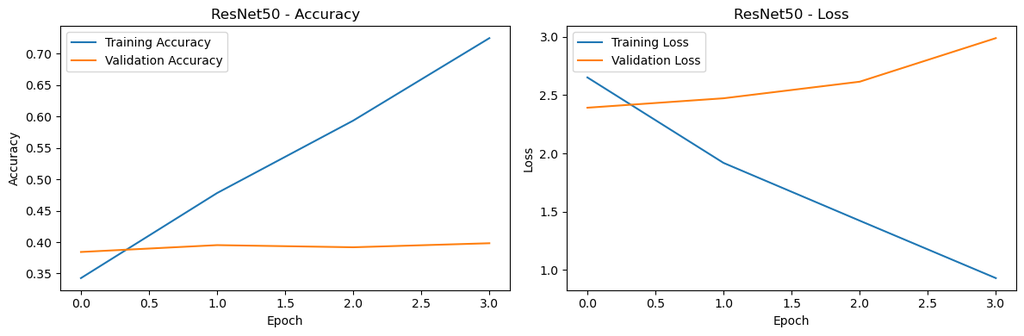

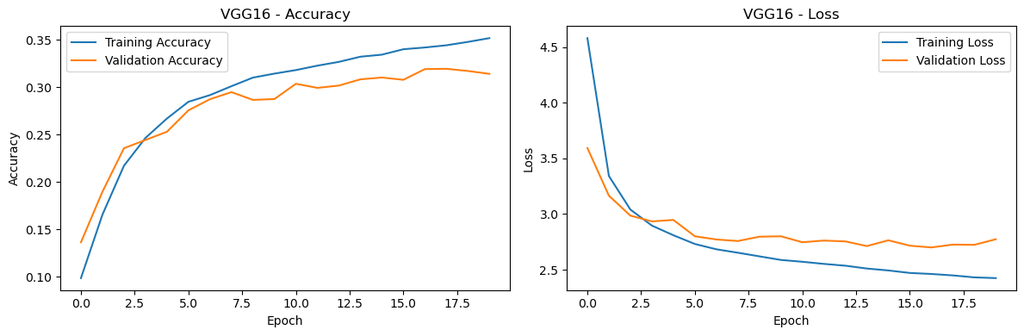

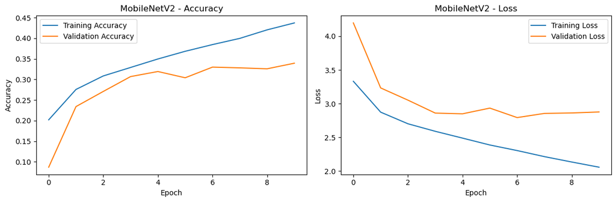

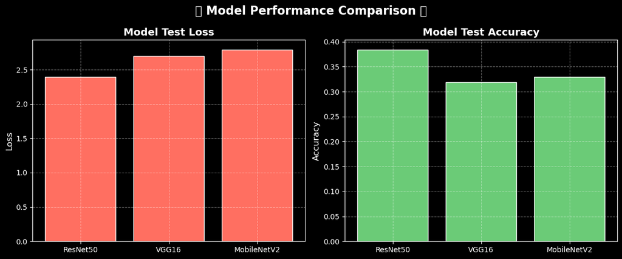